# K-12 to MELCs Curriculum

Initial Insights

Shaine Rosewel P. Matala

## At a Glance

At first glance, it is easy to say that the K-12 curriculum has been trimmed down. The question of whether the reduction is meaningful and significant is yet to be answered. By observation, the difference in the number of learning competencies from Kinder to Grade 6 are generally higher than from those that remain (high school, in particular). Note that for plotting, DepEd provided codes were used as bases.

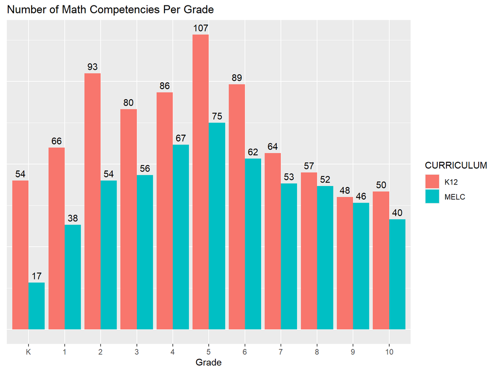

The curriculum is supposed to be spiral. In our context, this is how spiraling looks like, according to DepEd. The question is, is it supposed to be really like this? Guided by the principles and theories in education, do these panels suggest that we have a nicely weaved curriculum? Where is Stats and Prob in grades 8 and 9 when it is present in grades 7 and 10? Are we not mistaken? Is there really a gap? (In fact there is an error in the codes presented by DepEd. Read further (Wrong codes section) to see. Grade 8 has stats and prob. But still, grade 9 manifests the gap.)

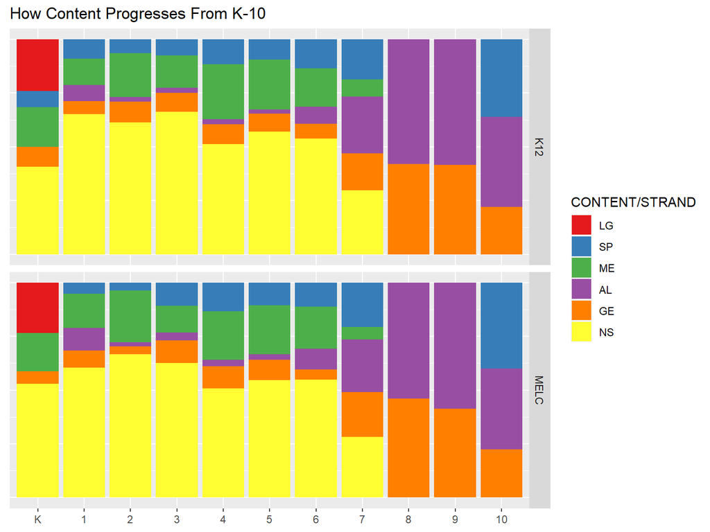

| GRADE | CONTENT/STRAND | K12_LC | K12_CODE | MELC_LC | MELC_CODE |
| --- | --- | --- | --- | --- | --- |
| 00 | LG | Describe objects based on attributes/properties (shapes, size, its use and functions) | MKSC-00-4 |  |  |
| 00 | LG | Group objects that are alike | MKSC-00-5 |  |  |
| 00 | LG | Match object, pictures based on properties /attributes in one-to-one correspondence - object to object - object to picture - picture to picture | MKAT-00-1 |  |  |
| 00 | LG | Sort and classify objects according to one attribute/property (shape, color, size, function/use) | MKSC-00-6 | Sort and classify objects according to one attribute/property (shape, color, size, function/use) | MKSC-00-6 |
| 00 | LG | Identify sequence of events (before, after, first, next, last) | MKSC-00-9 | Identify sequence of events (before, after, first, next, last) | MKSC-00-9 |
| 00 | LG | Arrange objects one after another in a series/sequence according to a given attribute (size, length) and describe their relationship (big/bigger/biggest or long/longer/longest) | MKSC-00-10 | Arrange objects one after another in a series/sequence according to a given attribute (size, length) and describe their relationship (big/bigger/biggest or long/longer/longest) | MKSC-00-10 |
| 00 | LG | Complete patterns | MKSC-00-19 |  |  |
| 00 | LG | Reproduce and extend patterns | MKSC-00-20 |  |  |
| 00 | LG | Create own patterns | MKSC-00-21 |  |  |
| 00 | LG | Transform/translate patterns from one form to another | MKSC-00-22 |  |  |

[output cut: 784 more lines]

The question we are dying to address: Was there really a reduction in the number of learning competencies? Let us have a real quick view.

## Problems to begin with

### Duplicated LC

There is one `K12_LC` in the K12 curriculum that is duplicated. Notice that they are differently coded, too. (hit the right arrow to see)

| K12_LC | K12_CODE |
| --- | --- |
| visualizes and describes the different solid figures: cube, prism, pyramid, cylinder, cone, and sphere. | M6GE-IIIa-27 |
| visualizes and describes the different solid figures: cube, prism, pyramid, cylinder, cone, and sphere. | M6GE-IIIc-31 |

This was actually addressed in MELC by writing a `MELC_LC`, which I coded as `NEW` just because I am not sure to which it is exactly is equivalent to in the K12 curriculum.

| MELC_LC | MELC_CODE |
| --- | --- |
| visualizes and describes the different solid figures: cube, prism, pyramid, cylinder, cone, and sphere using various concrete and pictorial models. | NEW |

### Duplicated CODES

UPDATE (12-15-2020): More duplicated codes found in K12 Kinder.

| GRADE | CONTENT/STRAND | K12_LC | K12_CODE | MELC_LC | MELC_CODE | QUARTER | WEEK | WITH_OTHER_LC_W/IN_WEEK | INDICATOR |
| --- | --- | --- | --- | --- | --- | --- | --- | --- | --- |
| 00 | NS | Rote count up to 20 | MKSC-00-12 | Rote count up to 20 | MKSC-00-12 | Q3 | Week 6 | No | NA |
| 00 | NS | Recognize the words “take away,” “less,” and “are left” that indicate the act of subtracting whole numbers | MKAT-00-4 | Recognize the words “take away,” “less,” and “are left” that indicate the act of subtracting whole numbers | MKAT-00-4 | Q4 | Week 8 | Yes | NA |
| 00 | NS | Take away a quantity from a given set using concrete objects to represent the concept of subtraction | MKAT-00-4 | NA | NA | NA | NA | NA | NA |
| 00 | NS | Use a variety of materials and communicate strategies used to determine answers to addition and subtraction problems listened to | MKAT-00-10 | NA | NA | NA | NA | NA | NA |
| 00 | NS | Write addition and subtraction number sentences using concrete representations | MKAT-00-10 | Write addition and subtraction number sentences using concrete representations | MKAT-00-10 | Q4 | Week 10 | No | NA |
| 00 | GE | Identify the positions of the objects using "in," "on," "over," "under," "top," and "bottom" | MKSC-00-12 | NA | NA | NA | NA | NA | NA |

In the manual checking of MELC, one `MELC_LC` was observed to be duplicated as it appears in two different quarters. Not sure if DepEd really wants it this way.

| MELC_LC | MELC_CODE | QUARTER | WEEK |
| --- | --- | --- | --- |
| Tell that the quantity of a set of objects does not change even though the arrangement has changed (i.e., the child should be able to tell that one set of counters placed in one-to-one correspondence … | MKSC-00-23 | Q2_Q3 | Week 5_Week 8 |

### Wrong codes

One strand in G8 is wrongly coded. It would appear that the codes are not 100% reliable. This error has been radiated to MELC as well. My wish is that for DepEd to be transparent on the information on how the codes were assigned by providing a short discussion about it within the curriculum, so that the meanings will make sense and allow errors such as this to be reported ASAP by curriculum users.

| K12_LC | K12_CODE | MELC_LC | MELC_CODE |
| --- | --- | --- | --- |
| illustrates an experiment, outcome, sample space and event.*** | M8GE-IVf-1 | illustrates an experiment, outcome, sample space and event. | M8GE-IVf-1 |
| counts the number of occurrences of an outcome in an experiment: (a) table; (b) tree diagram; (c) systematic listing; and (d) fundamental counting principle.*** | M8GE-IVf-g-1 | counts the number of occurrences of an outcome in an experiment: (a) table; (b) tree diagram; (c) systematic listing; and (d) fundamental counting principle. | M8GE-IVf-g-1 |
| finds the probability of a simple event. | M8GE-IVh-1 | finds the probability of a simple event. | M8GE-IVh-1 |
| illustrates an experimental probability and a theoretical probability. | M8GE-IVi-1 | illustrates an experimental probability and a theoretical probability. | M8GE-IVi-1 |
| solves problems involving probabilities of simple events. | M8GE-IVi-j-1 | solves problems involving probabilities of simple events. | M8GE-IVi-j-1 |

## Changes as they say

What I did is to compare the competencies from the K12 curriculum to those in the MELC curriculum and to indicate in the `MELC_CODE` which `K12_CODES` were merged to form the new `MELC_LC` `_` (underscore) was used to separate these merged `K12_CODE`. The worst case is that 6 `K12_CODE`s were all combined into one `MELC_LC`. This is not simply merging, in defense to DepEd. What they did is

1. reduce verbs  
   ex: “visualizes, represents, and compares” changed to “compares”
2. separated but related competencies were combined in one grand competency  
   ex: M1NS-IIa-26.1_M1NS-IIa-28.1a_M1NS-IIb-26.2_M1NS-IIb-27.1_M1NS-IIc-27.2_M1NS-IIc-27.3

| new.or.merged.melc |
| --- |
| M1NS-Id-6_M1NS-Ie-7 |
| M1NS-Ih-12.1_M1NS-Ih-13.1 |
| M1NS-Ii-16.1_M1NS-Ii-17.1 |
| M1NS-IIa-26.1_M1NS-IIa-28.1a_M1NS-IIb-26.2_M1NS-IIb-27.1_M1NS-IIc-27.2_M1NS-IIc-27.3 |
| M1NS-IIg-32.1_M1NS-IIg-32.2_M1NS-IIh-32.3_M1NS-IIh-32.4 |
| M1NS-IIIb-72.1_M1NS-IIIc-73 |
| NEW |
| M1AL-IIIg-1_M1AL-IIIg-2 |
| M1ME-IVd-20_M1ME-IVe-21_M1ME-IVf-22 |
| M2NS-Id-12.2_M2NS-Id-13.2 |

[output cut: 55 more lines]

Feel free to explore below the reduction that we are being told about. This shows the merging.

| GRADE | K12_LC | K12_CODE | MELC_LC | MELC_CODE |
| --- | --- | --- | --- | --- |
| 01 | visualizes, represents, and compares two sets using the expressions “less than,” “more than,” and “as many as.” | M1NS-Id-6 | compares two sets using the expressions “less than,” “more than,” and “as many as” and orders sets from least to greatest and vice versa. | M1NS-Id-6_M1NS-Ie-7 |
| 01 | visualizes, represents, and orders sets from least to greatest and vice versa. | M1NS-Ie-7 |  |  |
| 01 | visualizes, represents, and compares numbers up to 100 using relation symbols. | M1NS-Ih-12.1 | compares numbers up to 100 using relation symbol and orders them in increasing or decresing order. | M1NS-Ih-12.1_M1NS-Ih-13.1 |
| 01 | visualizes, represents, and orders numbers up to 100 in increasing or decreasing order. | M1NS-Ih-13.1 |  |  |
| 01 | identifies the 1st , 2nd, 3rd, up to 10th object in a given set from a given point of reference. | M1NS-Ii-16.1 | Identifies, reads and writes ordinal numbers: 1st , 2nd, 3rd, up to 10th object in a given set from a given point of reference. | M1NS-Ii-16.1_M1NS-Ii-17.1 |
| 01 | reads and writes ordinal numbers: 1st, 2nd, 3rd up to 10th. | M1NS-Ii-17.1 |  |  |
| 01 | visualizes and adds two one- digit numbers with sums up to 18 using the order and zero properties of addition. | M1NS-IIa-26.1 | visualizes and adds the following numbers using appropriate techniques: a. two one-digit numbers with sums up to 18 b. three one-digit numbers c. numbers with sums through 99 without and with regroupi… | M1NS-IIa-26.1_M1NS-IIa-28.1a_M1NS-IIb-26.2_M1NS-IIb-27.1_M1NS-IIc-27.2_M1NS-IIc-27.3 |
| 01 | adds two one-digit numbers using appropriate mental techniques e.g. adding doubles and/or near-doubles. | M1NS-IIa-28.1a |  |  |
| 01 | visualizes and adds three one-digit numbers using the grouping property of addition. | M1NS-IIb-26.2 |  |  |
| 01 | visualizes and adds two to three one-digit numbers horizontally and vertically. | M1NS-IIb-27.1 |  |  |

[output cut: 127 more lines]

This shows the newly stated `MELC_LC`. I coded these as `NEW` because DepEd did not code them with a `K12_CODE` and so I assume that these are either 1. new competencies or 2. a mix of many `K12_LC`s. However, I can’t exactly point out which ones were merged. It appears that 2nd there could be coded similarly to how it was in `K12_CODE`. I am not sure tho because DepEd only used `K12_CODE` for exact matches only.

| K12_LC | K12_CODE | MELC_LC | MELC_CODE |
| --- | --- | --- | --- |
| visualizes, and divides the elements of sets into two groups of equal quantities to show halves. | M1NS-IIIc-74.1 | visualizes, represents and divides the elements of sets into two groups of equal quantities to show halves and four groups of equal quantities to show fourths | NEW |
| visualizes, and represents, and solves problems involving conversion of time measure. | M3ME-IVb-10 | solves problems involving conversion of time measure. | NEW |
| divides 3- to 4-digit numbers by tens or hundreds or by 1 000 without and with remainder. | M4NS-If-54.4 | divides mentally 2- to 4-digit numbers by tens or hundreds or by 1 000 without and with remainder. | NEW |
| visualizes and describes the different solid figures: cube, prism, pyramid, cylinder, cone, and sphere. | M6GE-IIIa-27 | visualizes and describes the different solid figures: cube, prism, pyramid, cylinder, cone, and sphere using various concrete and pictorial models. | NEW |
| graphs polynomial functions. | M10AL-IIa-b-1 | understand, describe and interpret the graphs polynomial functions. | NEW |